# Operationalization

Tanya Bonilla

12/11/2019

# Loading in the Data

We begin with normal procedure; by loading in any data and files that are needed for analysis.

```r
library(knitr)
library(tidyverse)
library(MASS)

purl("p02_airbnb.Rmd", output = "second_del.r")
source("first_del.r")
source("second_del.r")
```

As I feel like there is more to discover in the *Airbnb: Data Modeling*, we will further explore the *New York Fields* data set.

## Creating a New Model & Cross-Validation

Let’s look at and define the new_york_fields tibble we created in *Data Modeling*. Here, we will look at the price compared to the neighborhood the data was cleansed from, the type of bed provided by the host, and the availability of the listing throughout the year. From the graph we can see that there is a positive correlation between availability and price.

```r
new_york_fields$bed_type <- as.factor(new_york_fields$bed_type)

model <- lm(price ~ neighbourhood_group_cleansed + bed_type + availability_365, data = new_york_fields)
model
```

```
##
## Call:
## lm(formula = price ~ neighbourhood_group_cleansed + bed_type +
##     availability_365, data = new_york_fields)
##
## Coefficients:
##                               (Intercept)
##                                  -28.0259
##      neighbourhood_group_cleansedBrooklyn
##                                  103.8581
##     neighbourhood_group_cleansedManhattan
##                                  118.4425
##        neighbourhood_group_cleansedQueens
##                                   36.8920
## neighbourhood_group_cleansedStaten Island
##                                  -18.2368
##                             bed_typeCouch
##                                   13.8381
##                             bed_typeFuton
##                                    1.5132
##                     bed_typePull-out Sofa
##                                    5.8803
##                          bed_typeReal Bed
##                                   66.4501
##                          availability_365
##                                    0.1088
```

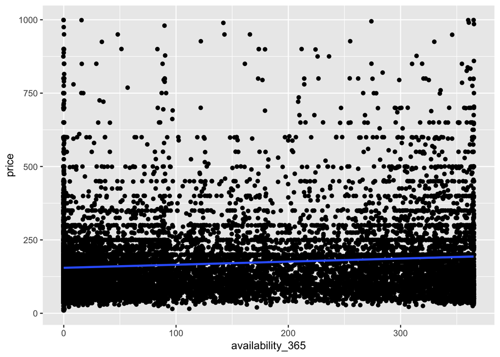

```r
ggplot(model, aes(x = availability_365, y =price))+ geom_jitter() + geom_smooth(method= lm)
```

```r
set.seed(385)
sample_selection <- createDataPartition(new_york_fields$price, p = 0.70, list = FALSE)
train <- new_york_fields[sample_selection,]
test <- new_york_fields[-sample_selection,]
train_model <- lm(price ~ neighbourhood_group_cleansed + bed_type + availability_365, data = train)
predictions <- train_model %>% predict(test)
```

## Explanation of Our Findings

```r
summary(train_model)
```

```
##
## Call:
## lm(formula = price ~ neighbourhood_group_cleansed + bed_type +
##     availability_365, data = train)
##
## Residuals:
##     Min      1Q  Median      3Q     Max
## -171.61  -77.87  -30.64   37.97  841.13
##
## Coefficients:
##                                             Estimate Std. Error t value
## (Intercept)                               -28.037206  62.366253  -0.450
## neighbourhood_group_cleansedBrooklyn      116.019063  64.808435   1.790
## neighbourhood_group_cleansedManhattan     118.979243  60.883684   1.954
## neighbourhood_group_cleansedQueens         36.458217  63.260408   0.576
## neighbourhood_group_cleansedStaten Island -18.052908 136.107664  -0.133
## bed_typeCouch                              14.636206  23.295434   0.628
## bed_typeFuton                              -2.391716  17.844910  -0.134
## bed_typePull-out Sofa                       1.557123  17.253453   0.090
## bed_typeReal Bed                           66.923489  13.495397   4.959
## availability_365                            0.106448   0.008652  12.303
##                                           Pr(>|t|)
## (Intercept)                                 0.6530
## neighbourhood_group_cleansedBrooklyn        0.0735 .
## neighbourhood_group_cleansedManhattan       0.0507 .
## neighbourhood_group_cleansedQueens          0.5644
## neighbourhood_group_cleansedStaten Island   0.8945
## bed_typeCouch                               0.5298
## bed_typeFuton                               0.8934
## bed_typePull-out Sofa                       0.9281
## bed_typeReal Bed                          7.19e-07 ***
## availability_365                           < 2e-16 ***
## ---
## Signif. codes:  0 '***' 0.001 '**' 0.01 '*' 0.05 '.' 0.1 ' ' 1
##
## Residual standard error: 121.7 on 11159 degrees of freedom
## Multiple R-squared:  0.02354,    Adjusted R-squared:  0.02275
## F-statistic: 29.89 on 9 and 11159 DF,  p-value: < 2.2e-16
```

```r
R2(predictions, test$price)
```

```
## [1] 0.0228846
```

```r
MAE(predictions, test$price)
```

```
## [1] 80.80336
```

## Operationalization

We can use the data that we have collected and models we have created to inform consumers of what places in New York are cheaper to look at when considering staying in New York. This could cause potential consumers to be more economical in their trips and be willing to use Airbnb more.

## Social Impact & Consequences

Some consequences that could come from informing consumers about such findings though are that some hosts on Airbnb could lose revenue due to the change in consumer wants. Say their place is nice menaing their price is higher, then there is a chance a potential client could look elsewhere. Another consequence would be that small-business motels/inns or B8B’s lose clientele as well.

## What next…

When I first began this project, I had a vision to coompare hotel listings with those of Airbnb’s, but I could not find a suitable dataset that would allow me to conduct such an analysis. A future goal for this assignment would be to compile data of hotel prices in New York over a span of time and compare them to those of Airbnb’s.